# Part II - Exploring Ford GoBike System Data to Increase Business

## by Gurinder Arora

## Investigation Overview

> In this investigation, I want to explore the dataset to find out a key solution to add further users in the system, which in term would would benefit both the business and the environment.

## Dataset Overview

> This dataset is provided by Udacity for a manual download. For GoBike is a regional public bike sharing system in San Francisko Bay Area. The dataset covers over 180K records of individual rides made in February 2019.

## Trip Duration

> The viz below shows the concentration of the trip duration in minutes. According to this viz, it is clear that the average ride is around 10 minutes of duration.

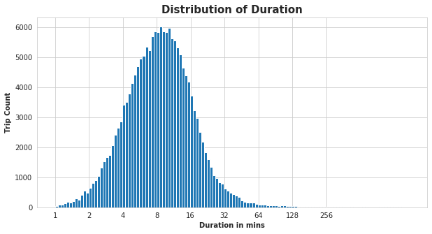

## Most common hours for the bike trips in relation to gender

> The viz below shows the most common hours for the bike ride and also the ratio of male and female users. According to this viz and the dataset, the males contribute to 75% of the bike rides. According to the population data of the area, females are outnumbered by 1.04 ratio to male, which in no way justifies the number of bike rides according to gender.

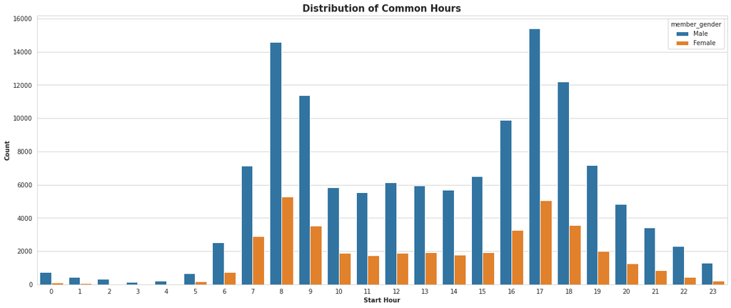

## Relationship between trip duration, subscriber type and gender

> The viz below shows the trip duration of male and female subscribers and non-subscriber users. The viz shows that the average trip duration of the female users is higher than the males, both as subscribers and non-subscribers. Plus the non-subscribed users have in general more minutes on the bike. These both factors could be very significant in going forward to acquiring more subscribed users to have a significant increase in the business.

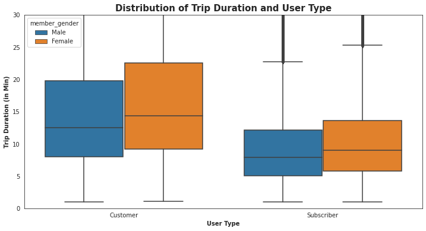